- Group Information
- Peak Calling Statistics
- Annotation of Peaks

# Azenta ChIP-seq Group Report

## 1. Group Information

| Customer | Anders Ohman |
| --- | --- |
| Email | anders_ohman@brown.edu |
| QuoteNumber | 30-858293328 |
| Configuration |  |
| Group | TA-2m1 |

## 2. Peak Calling Statistics

MACS2 2.1.2 was used to call peaks for each sample in group TA-2m1. Called peaks were merged within each group and peaks called in at least 2 samples were kept for downstream analysis.

| Sample | Number of Peaks |
| --- | --- |
| TA1-2m1 | 302 |
| TA2-2m1 | 586 |
| Merged | 52 |

## 3. Peak Annotation

### 3.1 Average ChIP-seq profile at annotated transcription start site (TSS) regions.

[figure not shown]

### 3.2 Peak annotation by genomic feature

Peaks were annotated based on the genomic features they overlap. When annotations overlap assignment priorities are: Promoter > 5’UTR > 3’UTR > Exon > Intron > Downstream > Intergenic.

Figure 3.2 Composition of peak overlaps with annotated genomic features

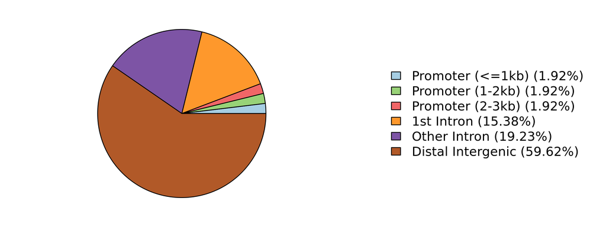

Figure 3.2 Composition of annotated peaks

Figure 3.3 Histogram of overlapping features under merged peaks, ranked by the number of peaks.

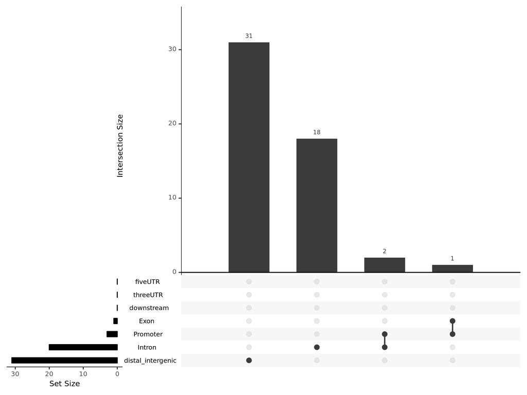

Figure 3.3 Overlapping genomic features by peak count

Figure 3.4 Distribution of genomic distances from peak summits to the nearest TSS.

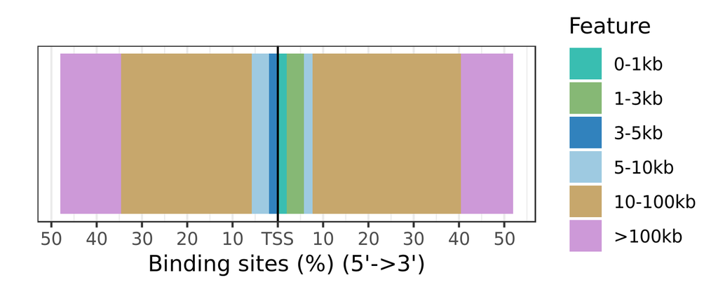

Figure 3.4 Distribution of genomic distance from peak summits to the nearest TSS

Table 3.1 First 100 peaks from the annotated peaks table.

| chr | start | end | strand | annotation | geneStart | geneEnd | geneStrand | geneId | transcriptId | distanceToTSS | gene_symbol | gene_name | gene_biotype | description |
| --- | --- | --- | --- | --- | --- | --- | --- | --- | --- | --- | --- | --- | --- | --- |
| 1 | 64338084 | 64338361 | * | Intron (ENSRNOT00000078444/ENSRNOG00000057848, intron 1 of 3) | 64330549 | 64330639 | 2 | ENSRNOG00000054831 | ENSRNOT00000086825 | -7445 | Mir935 | Mir935 | miRNA | microRNA 935 [Source:RGD Symbol;Acc:2314890] |
| 1 | 113258309 | 113258670 | * | Intron (ENSRNOT00000033811/ENSRNOG00000021507, intron 5 of 11) | 113346441 | 113347422 | 2 | ENSRNOG00000028324 | ENSRNOT00000030707 | 88752 |  | AABR07003504.1 | processed_pseudogene |  |
| 1 | 144922517 | 144922807 | * | Distal Intergenic | 144947023 | 144947154 | 1 | ENSRNOG00000058913 | ENSRNOT00000091008 | -24216 |  | ENSRNOG00000058913 | snoRNA | predicted gene, 22934 [Source:MGI Symbol;Acc:MGI:5452711] |
| 1 | 196315221 | 196315486 | * | Distal Intergenic | 196399025 | 196415261 | 2 | ENSRNOG00000057349 | ENSRNOT00000086583 | 99775 |  | AABR07005758.1 | lincRNA |  |
| 1 | 237655313 | 237655652 | * | Distal Intergenic | 237574788 | 237575252 | 1 | ENSRNOG00000031086 | ENSRNOT00000042738 | 80525 |  | AABR07006504.1 | protein_coding |  |
| 1 | 248307584 | 248307900 | * | Intron (ENSRNOT00000067612/ENSRNOG00000011599, intron 17 of 20) | 248297656 | 248376750 | 2 | ENSRNOG00000011599 | ENSRNOT00000089073 | 68850 | Gldc | Gldc | protein_coding | glycine decarboxylase [Source:RGD Symbol;Acc:1308660] |
| 10 | 6986435 | 6986717 | * | Intron (ENSRNOT00000046232/ENSRNOG00000025496, intron 1 of 30) | 6975244 | 7018930 | 1 | ENSRNOG00000025496 | ENSRNOT00000046232 | 11191 | Usp7 | Usp7 | protein_coding | ubiquitin specific peptidase 7 [Source:RGD Symbol;Acc:1306915] |
| 10 | 92323605 | 92323900 | * | Intron (ENSRNOT00000006947/ENSRNOG00000005133, intron 1 of 9) | 92337879 | 92382637 | 1 | ENSRNOG00000005133 | ENSRNOT00000042984 | -13979 | Mapt | Mapt | protein_coding | microtubule-associated protein tau [Source:RGD Symbol;Acc:69329] |
| 10 | 98687845 | 98688156 | * | Distal Intergenic | 98706960 | 98823287 | 1 | ENSRNOG00000004437 | ENSRNOT00000006217 | -18804 | Map2k6 | Map2k6 | protein_coding | mitogen-activated protein kinase kinase 6 [Source:RGD Symbol;Acc:620666] |
| 11 | 6018707 | 6019039 | * | Distal Intergenic | 5785788 | 5785898 | 2 | ENSRNOG00000049379 | ENSRNOT00000073838 | -232809 |  | 5S_rRNA | rRNA | 5S ribosomal RNA [Source:RFAM;Acc:RF00001] |

[output cut: 42 more lines]

- Azenta Life Sciences
- Next Generation Sequencing
- Email: ngs@azenta.com
- Phone: 908-222-0711 ext 1